# Building_Energy_Efficiency_part1

#### **Error by Building: Top 10 Buildings with Highest Mean Absolute Error**

Analyzing prediction errors by individual buildings helps identify specific locations where the model struggles most.

The top 10 buildings with the **highest mean absolute error (MAE)** are:

| Rank | Building ID | Mean Absolute Error (kWh) |
| --- | --- | --- |
| 1 | 778 | 7.711 |
| 2 | 50 | 2.060 |
| 3 | 1015 | 1.456 |
| 4 | 1088 | 0.935 |
| 5 | 765 | 0.411 |
| 6 | 55 | 0.346 |
| 7 | 60 | 0.321 |
| 8 | 1289 | 0.317 |
| 9 | 1349 | 0.315 |
| 10 | 9 | 0.305 |

**Insight**:

Building **778** stands out significantly, with an MAE far higher than others. This could indicate unusual consumption patterns, sensor issues, or modeling limitations specific to that building.

- **Error by hour of day**

```python
df = chilled_water_train_dummy

# Recover hour from hour_sin and hour_cos
recovered_hour = np.arctan2(df['hour_sin'], df['hour_cos'])  # angle in radians
recovered_hour = np.degrees(recovered_hour)  # convert to degrees
recovered_hour = (recovered_hour + 360) % 360  # ensure positive angles
recovered_hour = (recovered_hour * 24) / 360   # scale to 0–24
recovered_hour = recovered_hour.round().astype(int) % 24  # round and wrap to 0–23
val_df['hour'] = recovered_hour
```

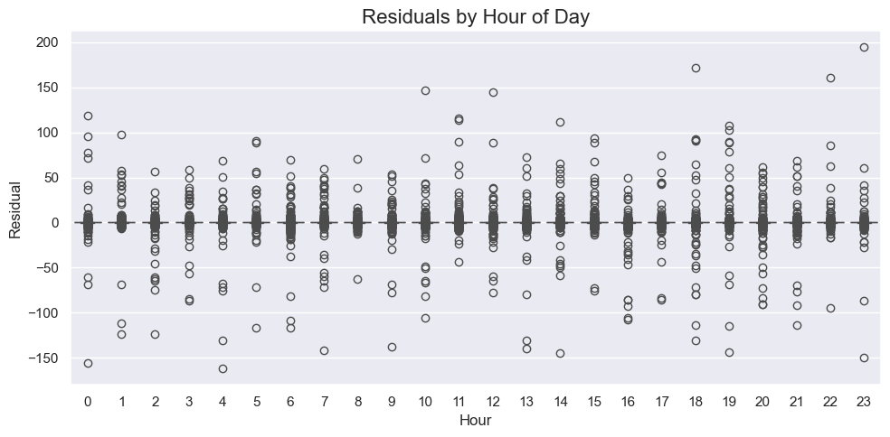

```python
# Plot
plt.figure(figsize=(10, 5))
sns.boxplot(x=val_df['hour'], y=val_df['residual'])

plt.title("Residuals by Hour of Day", fontsize=16)
plt.xlabel("Hour", fontsize=12)
plt.ylabel("Residual", fontsize=12)

#plt.ylim(-10., 10.)
plt.xticks(fontsize=11)
plt.yticks(fontsize=11)
plt.tight_layout()
plt.show()
```

#### **Residuals by hour of day**

- For **all hours (0–23)**, the residuals are **centered around 0**, typically falling within a symmetric range of **-100 to 100** kWh.
- However, there is a **notable presence of outliers**, especially:
  - On the **negative side**, between **-150 and -200** kWh
  - On the **positive side**, between **100 and 200** kWh

**Insight**:  
The general error distribution is well-behaved across the day, but large outliers—potentially due to extreme conditions or model underperformance on specific buildings—warrant further investigation.

- **Error by air temperature**

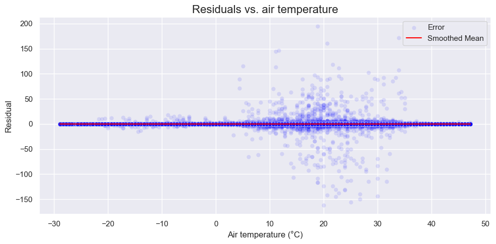

```python
plt.figure(figsize=(10, 5))

sns.scatterplot(x=val_df['air_temperature'], y=val_df['residual'], alpha=0.1, color='blue', label='Error')
sns.lineplot(x=val_df['air_temperature'], y=val_df['residual'].rolling(5000).mean(), color='red', label='Smoothed Mean')

plt.title("Residuals vs. air temperature", fontsize=16)
plt.xlabel("Air temperature (°C)", fontsize=12)
plt.ylabel("Residual", fontsize=12)

#plt.ylim(-1., 1.5)
plt.xticks(fontsize=11)
plt.yticks(fontsize=11)
plt.tight_layout()
plt.show()
```

#### **Residuals by air temperature**

1. **From -30°C to -5°C**:
   - Residuals are **very close to 0**, indicating stable model performance in cold conditions.
   - However, **some outliers exist**, with values ranging from **-15 to +15** kWh.
2. **From -5°C to 35°C**:
   - Residuals remain **centered around 0**, but show **greater dispersion**, extending to **±100 kWh**.
   - A number of **extreme outliers** also appear **outside this range**, suggesting performance variance under varying moderate temperatures.
3. **Above 35°C**:
   - Residuals are **very close to 0**, and **no significant outliers** are observed.
   - Indicates **strong model stability** during high-temperature conditions.

**Insight**:  
Model performance is most stable in very cold and very hot extremes, while **greater error variability occurs in the moderate temperature range** (-5°C to 35°C), likely due to more dynamic and complex demand behavior.

### **Save with joblib**

```python
import joblib

joblib.dump(model_orig_chil, "C:/Disc D/Projects to publish/Projects to do/Energy Efficiency Analytics in Buildings/chilled_water_lgbm_model.pkl")
```

```
['C:/Disc D/Projects to publish/Projects to do/Energy Efficiency Analytics in Buildings/chilled_water_lgbm_model.pkl']
```

## **3. Hot Water**

```python
# Load child water database
hot_water_train = pd.read_csv("C:/Disc D/Projects to publish/Projects to do/Energy Efficiency Analytics in Buildings/hot_water_train.csv")
```

```python
hot_water_train.shape
```

```
(1264037, 31)
```

### **Feature Engineering & data preparation**

**Enhance the dataset by adding useful dummied features and interaction features**

#### **a. Creating dummy variables for `site_id`, `primary_use` and `season` features**

```python
# Copying 'df_train_combined' dataframe into 'df_train_combined_dummy' dataframe
hot_water_train_dummy = hot_water_train.copy()

# Generate dummy variables and concatenate
for col in ["site_id", "primary_use", "season"]:
    dummies = pd.get_dummies(hot_water_train_dummy[col], prefix=col, drop_first=True)
    hot_water_train_dummy = pd.concat([hot_water_train_dummy, dummies], axis=1)
```

```python
hot_water_train_dummy.head(2)
```

|  | building_id | Energy_type | timestamp | site_id | primary_use | year_built | air_temperature | cloud_coverage | dew_temperature | precip_depth_1_hr | sea_level_pressure | wind_direction | wind_speed | square_meters | Energy_kWh | hour | dayofweek | month | is_weekend | is_work_hour | season | hour_sin | hour_cos | dayofweek_sin | dayofweek_cos | month_sin | month_cos | building_age | era_bin | … |
| --- | --- | --- | --- | --- | --- | --- | --- | --- | --- | --- | --- | --- | --- | --- | --- | --- | --- | --- | --- | --- | --- | --- | --- | --- | --- | --- | --- | --- | --- | --- |
| 0 | 106 | 3 | 2016-01-01 00:00:00 | 1 | Education | 1966.0 | 3.8 | 0.0 | 2.4 | 0.0 | 1020.9 | 240.0 | 3.1 | 499.260722 | 0.0 | 0 | 4 | 1 | 0 | 0 | Winter | 0.0 | 1.0 | -0.433884 | -0.900969 | 0.5 | 0.866025 | 59.0 | 60–80 | … |
| 1 | 109 | 3 | 2016-01-01 00:00:00 | 1 | Education | 1953.0 | 3.8 | 0.0 | 2.4 | 0.0 | 1020.9 | 240.0 | 3.1 | 5295.006485 | 0.0 | 0 | 4 | 1 | 0 | 0 | Winter | 0.0 | 1.0 | -0.433884 | -0.900969 | 0.5 | 0.866025 | 72.0 | Pre-1960 | … |

```python
hot_water_train_dummy.shape
```

```
(1264037, 47)
```

**After feature engineering and dummying some features, the train dataset is composed of 1264037 rows and 47 columns.**

- **Convert boolean values (True/False) to binary integers (1/0).**

```python
# Boolean features
bool_cols = ['site_id_2', 'site_id_7', 'site_id_10','site_id_11', 'site_id_14','site_id_15',
             'primary_use_Entertainment/public assembly', 'primary_use_Food sales and service',
             'primary_use_Healthcare', 'primary_use_Lodging/residential', 'primary_use_Office',
             'primary_use_Public services', 'primary_use_Technology/science', 'season_Spring',
             'season_Summer', 'season_Winter']

hot_water_train_dummy[bool_cols] = hot_water_train_dummy[bool_cols].astype(int)
```

```python
hot_water_train_dummy.head(2)
```

|  | building_id | Energy_type | timestamp | site_id | primary_use | year_built | air_temperature | cloud_coverage | dew_temperature | precip_depth_1_hr | sea_level_pressure | wind_direction | wind_speed | square_meters | Energy_kWh | hour | dayofweek | month | is_weekend | is_work_hour | season | hour_sin | hour_cos | dayofweek_sin | dayofweek_cos | month_sin | month_cos | building_age | era_bin | … |
| --- | --- | --- | --- | --- | --- | --- | --- | --- | --- | --- | --- | --- | --- | --- | --- | --- | --- | --- | --- | --- | --- | --- | --- | --- | --- | --- | --- | --- | --- | --- |
| 0 | 106 | 3 | 2016-01-01 00:00:00 | 1 | Education | 1966.0 | 3.8 | 0.0 | 2.4 | 0.0 | 1020.9 | 240.0 | 3.1 | 499.260722 | 0.0 | 0 | 4 | 1 | 0 | 0 | Winter | 0.0 | 1.0 | -0.433884 | -0.900969 | 0.5 | 0.866025 | 59.0 | 60–80 | … |
| 1 | 109 | 3 | 2016-01-01 00:00:00 | 1 | Education | 1953.0 | 3.8 | 0.0 | 2.4 | 0.0 | 1020.9 | 240.0 | 3.1 | 5295.006485 | 0.0 | 0 | 4 | 1 | 0 | 0 | Winter | 0.0 | 1.0 | -0.433884 | -0.900969 | 0.5 | 0.866025 | 72.0 | Pre-1960 | … |

#### **b. Add the interaction features**

```python
# Add interaction features
hot_water_train_dummy = add_interaction_features(hot_water_train_dummy)
```

```python
hot_water_train_dummy.shape
```

```
(1264037, 132)
```

```python
hot_water_train_dummy.head(1)
```

|  | building_id | Energy_type | timestamp | site_id | primary_use | year_built | air_temperature | cloud_coverage | dew_temperature | precip_depth_1_hr | sea_level_pressure | wind_direction | wind_speed | square_meters | Energy_kWh | hour | dayofweek | month | is_weekend | is_work_hour | season | hour_sin | hour_cos | dayofweek_sin | dayofweek_cos | month_sin | month_cos | building_age | era_bin | … |
| --- | --- | --- | --- | --- | --- | --- | --- | --- | --- | --- | --- | --- | --- | --- | --- | --- | --- | --- | --- | --- | --- | --- | --- | --- | --- | --- | --- | --- | --- | --- |
| 0 | 106 | 3 | 2016-01-01 00:00:00 | 1 | Education | 1966.0 | 3.8 | 0.0 | 2.4 | 0.0 | 1020.9 | 240.0 | 3.1 | 499.260722 | 0.0 | 0 | 4 | 1 | 0 | 0 | Winter | 0.0 | 1.0 | -0.433884 | -0.900969 | 0.5 | 0.866025 | 59.0 | 60–80 | … |

#### **c. Split the dataset into train and test subsets**

```python
# List of features to drop
fet_to_drop3 = ['Energy_type', 'timestamp', 'site_id', 'primary_use', 'year_built', 'Energy_kWh', 'hour', 'dayofweek',
                'month', 'era_bin', 'season', 'energy_density_kwh_m2', 'air_temp_bin', 'strata_key']

# train dataset
X_hot_water = hot_water_train_dummy.drop(columns = [col for col in fet_to_drop3 if col in hot_water_train_dummy.columns])
y_hot_water = hot_water_train_dummy['energy_density_kwh_m2']
```

```python
# We split two dataframes with inputs and targets, each into a train and test dataframe, and store them in variables.
X_hot_train, X_hot_test, y_hot_train, y_hot_test = train_test_split(X_hot_water, y_hot_water, test_size=0.3, random_state=42, shuffle=True)
```

```python
# Shape of train and test data subsets
print('Train subset shape: ', X_hot_train.shape)
print('Test subset shape: ', X_hot_test.shape)
```

```
Train subset shape:  (884825, 120)
Test subset shape:  (379212, 120)
```

- The train dataset is composed of **884,825 rows** and **120 independant features**.
- The test dataset is composed of **379,212 rows** and **120 independant features**.

#### **d. Checking for Outliers**

- **Distribution Plot**

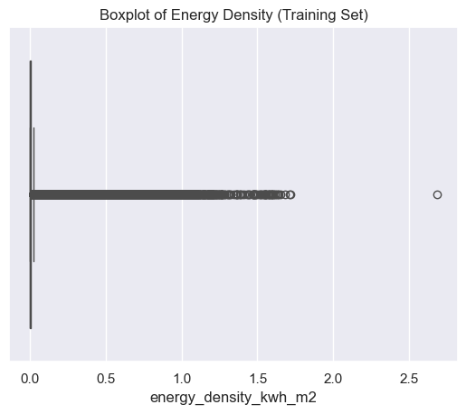

```python
# Example for Energy_kWh
sns.boxplot(x = y_hot_train)
plt.title("Boxplot of Energy Density (Training Set)")
plt.show()
```

As can be observed on the figure, there are a lot of outliers.

- **IQR method**

```python
Q1 = y_hot_train.quantile(0.25)
Q3 = y_hot_train.quantile(0.75)
IQR = Q3 - Q1

outlier_mask = (y_hot_train < (Q1 - 1.5 * IQR)) | (y_hot_train > (Q3 + 1.5 * IQR))
print(f"Outliers: {outlier_mask.sum()} / {len(y_hot_train)}")
```

```
Outliers: 85743 / 884825
```

For energy density, we have about **85,743 outliers out of 884,825 rows** — that's only **~9.7%** of our data.

### **LGBMRegressor Model**

#### **a. IQR Outlier Handling**

Train the model, with "Energy Density" as target variable, on:

- **Original data**
- **Cleaned data (IQR-filtered)**
- **Clipped data (IQR-capped)**

```python
# ----- 1. Clip feature values (optional, for stability) -----
def iqr_clip_columns_inplace(df, cols=None, iqr_multiplier=1.5):
    if cols is None:
        cols = df.select_dtypes(include=np.number).columns

    for col in cols:
        q1 = df[col].quantile(0.25)
        q3 = df[col].quantile(0.75)
        iqr = q3 - q1
        lower = q1 - iqr_multiplier * iqr
        upper = q3 + iqr_multiplier * iqr
        df[col] = df[col].clip(lower=lower, upper=upper)

    return df

# Apply feature clipping
X_capped_hot = iqr_clip_columns_inplace(X_hot_train.copy())

# ----- 2. Compute target variable outliers -----
Q1 = y_hot_train.quantile(0.25)
Q3 = y_hot_train.quantile(0.75)
IQR = Q3 - Q1
lower_bound = Q1 - 1.5 * IQR
upper_bound = Q3 + 1.5 * IQR

outlier_mask = (y_hot_train < lower_bound) | (y_hot_train > upper_bound)
print(f"Outliers in target: {outlier_mask.sum()} / {len(y_hot_train)}")

# ----- Option A: Clip the target variable -----
y_capped_hot = y_hot_train.clip(lower=lower_bound, upper=upper_bound)

# ----- Option B: Filter out outlier rows completely -----
X_filtered_hot = X_capped_hot[~outlier_mask]
y_filtered_hot = y_hot_train[~outlier_mask]
```

```
Outliers in target: 85743 / 884825
```

```python
X_hot_train.shape
```

```
(884825, 120)
```

```python
X_filtered_hot.shape
```

```
(799082, 120)
```

**The dataset without outliers is composed by 799,082 rows.**

#### **b. Train models and compare**

```python
# Original data
model_orig_hot = train_lgbm(X_hot_train, y_hot_train)
pred_orig_hot = model_orig_hot.predict(X_hot_test)
evaluate_model("Original", y_hot_test, pred_orig_hot)

# IQR-filtered data
model_filtered_hot = train_lgbm(X_filtered_hot, y_filtered_hot)
pred_filtered_hot = model_filtered_hot.predict(X_hot_test)
evaluate_model("Filtered (IQR removed)", y_hot_test, pred_filtered_hot)

# IQR-capped data
model_capped_hot = train_lgbm(X_capped_hot, y_capped_hot)
pred_capped_hot = model_capped_hot.predict(X_hot_test)
evaluate_model("Capped (IQR clipped)", y_hot_test, pred_capped_hot)
```

```
[LightGBM] [Warning] Found whitespace in feature_names, replace with underlines
[LightGBM] [Info] Auto-choosing col-wise multi-threading, the overhead of testing was 0.501631 seconds.
You can set `force_col_wise=true` to remove the overhead.
[LightGBM] [Info] Total Bins 8162
[LightGBM] [Info] Number of data points in the train set: 884825, number of used features: 120
[LightGBM] [Info] Start training from score 0.010551
--- Original ---
RMSE: 0.02244741186248448
MAE: 0.004768469408667761
Median AE: 0.0011029606350796617
R²: 0.6779835383368537
SMAPE: 98.30 %

[LightGBM] [Warning] Found whitespace in feature_names, replace with underlines
[LightGBM] [Info] Auto-choosing col-wise multi-threading, the overhead of testing was 0.131156 seconds.
You can set `force_col_wise=true` to remove the overhead.
[LightGBM] [Info] Total Bins 5884
[LightGBM] [Info] Number of data points in the train set: 799082, number of used features: 47
[LightGBM] [Info] Start training from score 0.004574
--- Filtered (IQR removed) ---
RMSE: 0.038611833242009806
MAE: 0.006270522693306653
Median AE: 0.0007171949902787948
R²: 0.0472337440895394
SMAPE: 94.02 %

[LightGBM] [Warning] Found whitespace in feature_names, replace with underlines
[LightGBM] [Info] Auto-choosing col-wise multi-threading, the overhead of testing was 0.151036 seconds.
You can set `force_col_wise=true` to remove the overhead.
[LightGBM] [Info] Total Bins 5886
[LightGBM] [Info] Number of data points in the train set: 884825, number of used features: 47
[LightGBM] [Info] Start training from score 0.006846
--- Capped (IQR clipped) ---
RMSE: 0.03733241707454072
MAE: 0.005719145044362061
Median AE: 0.0007851724749819624
R²: 0.1093281186922277
SMAPE: 92.66 %
```

#### **Interpretations:**

**1. Model Setup Summary**

- **Target Variable:** Energy density for hot water
- **Model:** LightGBM
- **Dataset Size:**
  - **Original:** 884,825 rows, 120 features
  - **Filtered:** 799,082 rows, 47 features
  - **Capped:** 884,825 rows, 47 features

**2. Performance Metrics Comparison**

| **Metric** | **Original** | **Filtered (IQR removed)** | **Capped (IQR clipped)** |
| --- | --- | --- | --- |
| **RMSE** | 0.0224 | 0.0386 | 0.0373 |
| **MAE** | 0.0048 | 0.0063 | 0.0057 |
| **Median AE** | 0.0011 | 0.0007 | 0.0008 |
| **R²** | 0.678 | 0.047 | 0.109 |
| **SMAPE** | 98.30% | 94.02% | 92.66% |

**3. Key Takeaways**

- **Original Dataset** (no filtering/clipping):
  - Achieves the **highest R² (0.678)** and **lowest RMSE and MAE**.
  - But SMAPE is **very high (98.3%)**, likely due to **extreme values affecting percentage-based error**.
- **Filtered Dataset** (outliers removed via IQR):
  - **R² drops dramatically (to 0.047)**, suggesting **loss of important data** when outliers were removed.
  - Slightly better SMAPE (94.02%) and very low median AE.
  - May have over-simplified the data.
- **Capped Dataset** (outliers capped via IQR):
  - Good compromise:
    - R² is **higher than filtered** (0.109), but still far below original.
    - SMAPE is **best overall (92.66%)**.
    - MAE and RMSE remain reasonable.

**4. Recommendations**

- **Keep the original dataset** if **explanation and general accuracy (R²)** are more important.
- Use the **capped dataset** if you want to **reduce the effect of extreme outliers** and improve **relative errors** like SMAPE.
- Avoid full IQR filtering — it hurts performance by discarding informative samples.
- Investigate **why SMAPE remains very high**:
  - SMAPE inflates when actual values are close to zero — check target distribution.
  - Consider filtering or transforming very small values in the denominator.

### **Feature importances**

- **Get N top important features**

```python
# Get absolute and relative importances
importances = model_orig_hot.feature_importances_
features = X_hot_water.columns
relative_importances = importances / importances.sum()

# Select the top N features
top_N = 75  # Change this to the desired number of features
top_features, top_importances = select_top_features(relative_importances, features, N=top_N)

print(f"Top {top_N} Features:")
print(' ')
for i, (feature, importance) in enumerate(zip(top_features, top_importances), 1):
    print(f"{i}. {feature}: {importance:.7f}")

Sum_top = top_importances.sum()
print(' ')
print(f" Sum of the Top {top_N} Features Importances: {Sum_top:.3f}")
```

```
Top 75 Features:

1. building_id: 0.1336333
2. square_meters: 0.0643000
3. sea_level_pressure_x_month_cos: 0.0593667
4. sea_level_pressure: 0.0529667
5. air_temperature: 0.0492667
6. hour_sin: 0.0411667
7. month_sin: 0.0340667
8. air_temperature_x_month_cos: 0.0339667
9. air_temperature_x_square_meters: 0.0327000
10. dew_temperature_x_month_cos: 0.0292333
11. dew_temperature: 0.0288000
12. primary_use_Entertainment/public assembly_x_hour_cos: 0.0263333
13. site_id_10: 0.0237000
14. primary_use_Entertainment/public assembly_x_dayofweek_cos: 0.0218000
15. dew_temperature_x_square_meters: 0.0209000
16. air_temperature_x_hour_cos: 0.0186667
17. dew_temperature_x_hour_cos: 0.0185667
18. wind_direction_x_month_cos: 0.0168000
19. wind_speed_x_month_cos: 0.0154000
20. wind_direction: 0.0149333
21. dayofweek_sin: 0.0145333
22. sea_level_pressure_x_hour_cos: 0.0140667
23. sea_level_pressure_x_is_weekend: 0.0137667
24. wind_speed_x_hour_cos: 0.0137000
25. building_age: 0.0126667
26. dayofweek_cos: 0.0126000
27. wind_speed_x_square_meters: 0.0118333
28. wind_direction_x_hour_cos: 0.0116333
29. square_meters_x_hour_cos: 0.0112000
30. sea_level_pressure_x_is_work_hour: 0.0087333
31. dew_temperature_x_is_weekend: 0.0086000
32. wind_speed: 0.0085667
33. air_temperature_x_is_weekend: 0.0068667
34. precip_depth_1_hr_x_month_cos: 0.0054667
35. square_meters_x_is_weekend: 0.0053000
36. month_cos: 0.0051667
37. precip_depth_1_hr_x_hour_cos: 0.0043333
38. primary_use_Entertainment/public assembly_x_season_Winter: 0.0042667
```

[output cut: 24 more lines]

```
63. air_temperature_x_is_modern_building: 0.0013667
64. cloud_coverage_x_month_cos: 0.0013000
65. building_age_x_is_work_hour: 0.0012000
66. primary_use_Entertainment/public assembly_x_is_work_hour: 0.0011000
67. season_Spring: 0.0010000
68. primary_use_Office_x_season_Spring: 0.0009667
69. primary_use_Healthcare_x_hour_cos: 0.0009000
70. primary_use_Healthcare: 0.0008333
71. building_age_x_is_weekend: 0.0007667
72. primary_use_Food sales and service_x_season_Spring: 0.0007667
73. site_id_14: 0.0007667
74. precip_depth_1_hr_x_is_weekend: 0.0007333
75. primary_use_Healthcare_x_season_Spring: 0.0007333

 Sum of the Top 75 Features Importances: 0.990
```

- **Get the top interaction features**

```python
# Convert to pandas Series first
top_features_series = pd.Series(top_features)

# Then filter and sort
top_intera_feats = top_features_series[top_features_series.str.contains('_x_')]
print(top_intera_feats)

print(len(top_intera_feats))
```

```
2                        sea_level_pressure_x_month_cos
7                           air_temperature_x_month_cos
8                       air_temperature_x_square_meters
9                           dew_temperature_x_month_cos
11    primary_use_Entertainment/public assembly_x_ho...
13    primary_use_Entertainment/public assembly_x_da...
14                      dew_temperature_x_square_meters
15                           air_temperature_x_hour_cos
16                           dew_temperature_x_hour_cos
17                           wind_direction_x_month_cos
18                               wind_speed_x_month_cos
21                        sea_level_pressure_x_hour_cos
22                      sea_level_pressure_x_is_weekend
23                                wind_speed_x_hour_cos
26                           wind_speed_x_square_meters
```

[output cut: 37 more lines]

**From these 75 top important features, 50 ones are interaction features.**

#### **Interpretations:**

**1. General Overview**

→ The model’s predictions rely almost entirely (~99%) on the top 75 features. This high concentration indicates that your feature selection and engineering are effective and comprehensive.

- **Number of interaction features in Top 75: 50**

→ Nearly **67%** of the top features are interaction features (e.g., `air_temperature_x_month_cos`), confirming their crucial role in capturing complex relationships affecting hot water energy usage.

**2. Most Important Features (Top 10)**

| Rank | Feature Name | Importance |
| --- | --- | --- |
| 1 | building_id | 0.1336 |
| 2 | square_meters | 0.0643 |
| 3 | sea_level_pressure_x_month_cos | 0.0594 |
| 4 | sea_level_pressure | 0.0530 |
| 5 | air_temperature | 0.0493 |
| 6 | hour_sin | 0.0412 |
| 7 | month_sin | 0.0341 |
| 8 | air_temperature_x_month_cos | 0.0340 |
| 9 | air_temperature_x_square_meters | 0.0327 |
| 10 | dew_temperature_x_month_cos | 0.0292 |

**Notes:**

- **Building attributes** such as `building_id` and `square_meters` dominate, which aligns with the idea that hot water usage is highly dependent on building-specific factors like type and size.
- **Weather variables**—especially `sea_level_pressure`, `air_temperature`, and their interactions—rank high, indicating that external environmental conditions significantly influence energy needs for hot water.
- **Time-of-day and seasonal cycles** via `hour_sin`, `month_sin`, and interactions like `*_x_month_cos` show strong temporal dependencies in usage patterns.

**3. Interaction Features**

Interaction features like `air_temperature_x_month_cos` or `dew_temperature_x_hour_cos` provide **context-aware non-linear effects**. They help the model learn how the effect of one variable (like temperature) changes depending on time, size, or building type.

🔹 Notable Interaction Types in Top 20:

- **Weather × Time:**
  - `air_temperature_x_month_cos`
  - `dew_temperature_x_month_cos`
  - `sea_level_pressure_x_month_cos`

→ These capture how seasonal patterns affect the sensitivity of hot water demand to environmental variables.

- **Building Size × Time:**
  - `air_temperature_x_square_meters`
  - `dew_temperature_x_square_meters`

→ Larger buildings might require more hot water, but their consumption patterns vary based on weather or time.

- **Usage Type × Time:**
  - `primary_use_Entertainment/public assembly_x_hour_cos`
  - `primary_use_Entertainment/public assembly_x_dayofweek_cos`

→ Different primary uses (like entertainment venues) show different patterns of hot water usage across hours and days.

- **Wind × Seasonality:**
  - `wind_direction_x_month_cos`
  - `wind_speed_x_month_cos`

→ Wind effects on building envelope heat loss might affect hot water needs in cold/windy months.

**4. Key Insights for Modeling**

| Insight | Interpretation |
| --- | --- |
| Building-specific features matter most | `building_id` and `square_meters` dominate → energy needs tied to structure |
| Weather variables are critical | `air_temperature`, `dew_temperature`, `sea_level_pressure` confirm dependence |
| Time-based interactions improve predictions | `hour_sin`, `month_sin`, and interaction features capture cyclic/seasonal trends |
| Interaction features boost predictive power | 50 of top 75 features are interactions → validates your feature engineering |
| Primary use patterns are behaviorally driven | `primary_use_*_x_*` interactions show behavior-linked hot water usage |

**5. Final Takeaway**

This analysis confirms that your model captures **multi-dimensional drivers of hot water energy density**, including:

- **Static building characteristics**
- **Dynamic environmental conditions**
- **Seasonal/temporal patterns**
- **Human activity cycles** (through primary use and time interactions)

The feature engineering pipeline is clearly adding substantial predictive value.

### **SHAP Values (Global & Local Interpretability)**

To better understand how each feature influences the model's predictions, we use SHAP (SHapley Additive exPlanations), a game-theoretic approach to explain individual predictions. SHAP values provide both global insights into feature importance and local explanations for specific instances.

#### **1. SHAP Setup**

```python
import shap

# Compute SHAP values
explainer = shap.TreeExplainer(model_orig_hot)
shap_values = explainer.shap_values(X_hot_test)
```

#### **2. SHAP Summary Plot (Global Importance)**

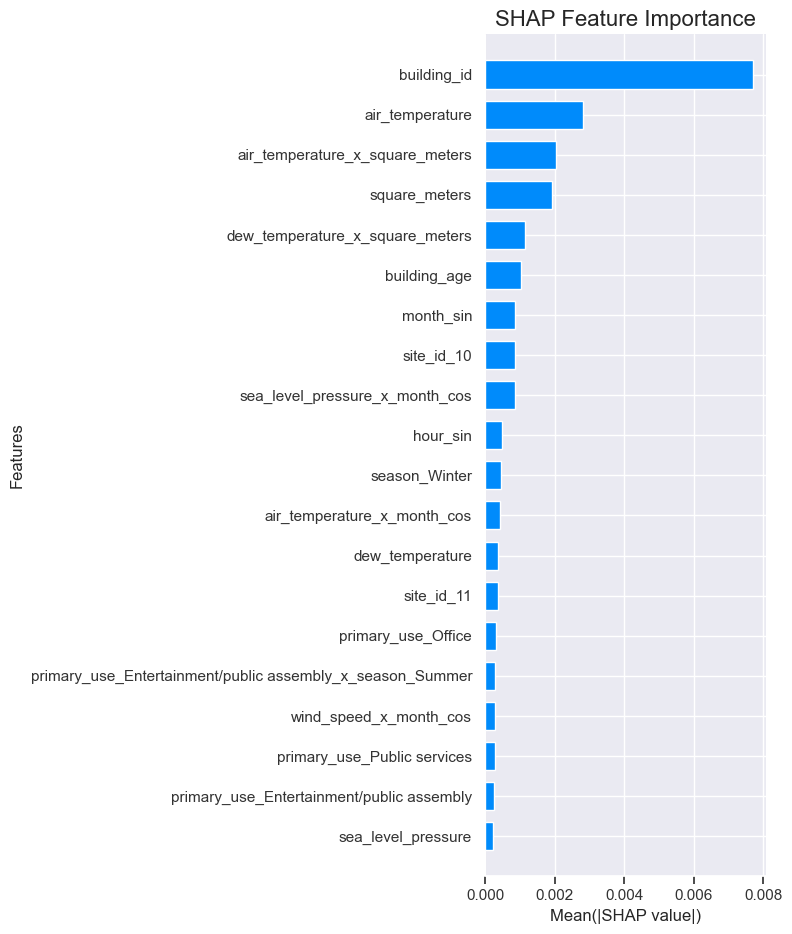

```python
# Create SHAP bar plot
shap.summary_plot(shap_values, X_hot_test, plot_type="bar", show=False)

# Customize title and label fonts
plt.title("SHAP Feature Importance", fontsize=16)
plt.xlabel("Mean(|SHAP value|)", fontsize=12)
plt.ylabel("Features", fontsize=12)

# Customize tick label size
plt.xticks(fontsize=11)
plt.yticks(fontsize=11)

# Show the customized plot
plt.tight_layout()
plt.show()
```

```python
# Convert to DataFrame for easier analysis
shap_df = pd.DataFrame(shap_values, columns= X_hot_test.columns)

# Compute mean absolute SHAP values per feature
mean_abs_shap = shap_df.abs().mean().sort_values(ascending=False)

# Select top 20 features
top_20_features = mean_abs_shap.head(20).index

# Extract SHAP values for these features
top_20_shap_values = shap_df[top_20_features]

# Display result
print("SHAP values of top 20 features:")
top_20_shap_values.abs().mean().sort_values(ascending=False)
```

```
SHAP values of top 20 features:
```

```
building_id                                                  0.007696
air_temperature                                              0.002803
air_temperature_x_square_meters                              0.002045
square_meters                                                0.001927
dew_temperature_x_square_meters                              0.001155
building_age                                                 0.001035
month_sin                                                    0.000853
site_id_10                                                   0.000844
sea_level_pressure_x_month_cos                               0.000843
hour_sin                                                     0.000472
season_Winter                                                0.000456
air_temperature_x_month_cos                                  0.000417
dew_temperature                                              0.000365
site_id_11                                                   0.000355
primary_use_Office                                           0.000314
primary_use_Entertainment/public assembly_x_season_Summer    0.000289
wind_speed_x_month_cos                                       0.000285
primary_use_Public services                                  0.000273
primary_use_Entertainment/public assembly                    0.000250
sea_level_pressure                                           0.000215
dtype: float64
```

#### **SHAP-based interpretation of model behavior**

**1. General Overview**

→ This shows that your model’s predictive behavior is largely driven by these top 20 features, reflecting **strong feature concentration**.

**Top feature (building_id): 0.0077**

→ building_id is by far the most impactful feature, suggesting **strong building-specific consumption patterns**.

**3. Key takeaways from SHAP analysis**

- **Building features dominate**

`building_id`, `square_meters`, and `building_age` contribute heavily → This reflects unique energy usage signatures for each building, emphasizing static infrastructure effects.

- **Weather & seasonality matter**

`air_temperature`, `dew_temperature`, `sea_level_pressure` and their interactions with time (e.g., `*_x_month_cos`) highlight environmental influences.

- **Interaction features are crucial**

Features like `air_temperature_x_square_meters`, `dew_temperature_x_square_meters`, and `*_x_month_cos` show how contextual effects (e.g., building size, time of year) modulate raw variables.

- **Time-based dynamics**

`month_sin`, `hour_sin`, and `season_Winter` indicate cyclical energy behavior, such as seasonal heating needs or working-hour trends.

- **Primary Use & Site Location Also Play a Role**

Features like `primary_use_*` and `site_id_10/11` suggest usage behavior and regional operational factors matter, but with less impact than building and weather features.

#### **3. SHAP Dependence (Nonlinear Interaction)**

- **Air-temperature**

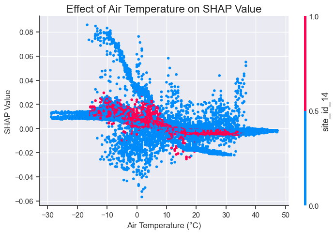

```python
# Plot SHAP dependence with show=False
shap.dependence_plot("air_temperature", shap_values, X_hot_test, show=False)

# Customize title and labels
plt.title("Effect of Air Temperature on SHAP Value", fontsize=16)
plt.xlabel("Air Temperature (°C)", fontsize=12)
plt.ylabel("SHAP Value", fontsize=12)

# Customize tick label size
plt.xticks(fontsize=11)
plt.yticks(fontsize=11)

# Adjust layout and show the customized plot
plt.tight_layout()
plt.show()
```

#### **SHAP Value Ranges by Air Temperature**

SHAP value analysis provides insights into how **air temperature** affects model predictions for hot water usage:

| Air temperature range (°C) | SHAP value range | Outliers present? | Interpretation |
| --- | --- | --- | --- |
| -30 to -15 | ~0.007 to 0.015 | No outliers | Consistent **positive contribution** to prediction at extreme cold; possibly due to heating demand. |
| -15 to 10 | -0.04 to 0.04 | Yes (up to 0.08) | Highly variable effect, suggesting **complex dynamics** in moderate cold. Some buildings may use hot water heavily in this zone. |
| 10 to 35 | -0.02 to 0.02 | Yes (up to 0.06) | Neutral to slightly variable impact — likely reflects **milder heating/cooling needs**. |
| >35 | ~-0.005 to 0 | No outliers | Consistently **slight negative impact** — likely due to **reduced hot water use** in extreme heat. |

**Key Takeaways:**

- **Cold temperatures** (especially below -15°C) consistently **increase model predictions**, pointing to **higher energy usage**.
- **Moderate ranges** (-15°C to 35°C) introduce **more variability and outliers**, which may reflect **building-specific heating patterns, occupancy behavior**, or **control systems**.
- **Very high temperatures (>35°C)** show **minimal and negative SHAP values**, indicating **lower hot water demand** — likely due to absence of heating and reduced overall energy use.

#### **4. Error distribution (Residuals)**

- **Histogram of Residuals**

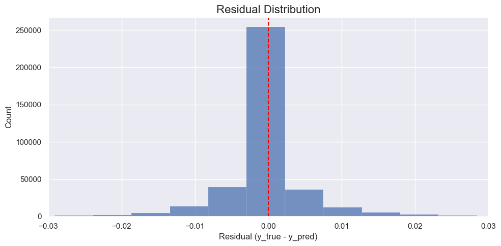

```python
residuals = y_hot_test - pred_orig_hot

plt.figure(figsize=(10, 5))
sns.histplot(residuals, bins=500, kde=False)
plt.axvline(0, color='red', linestyle='--')
plt.title("Residual Distribution", fontsize=16)
plt.xlabel("Residual (y_true - y_pred)", fontsize=12)

plt.xlim(-0.03, 0.03)
plt.xticks(fontsize=11)
plt.yticks(fontsize=11)
plt.tight_layout()
plt.show()
```

#### **Error Distribution (Residuals Analysis)**

[output not shown]

#### **5. Error analysis by building, time, and weather**

- **Error by building_id**

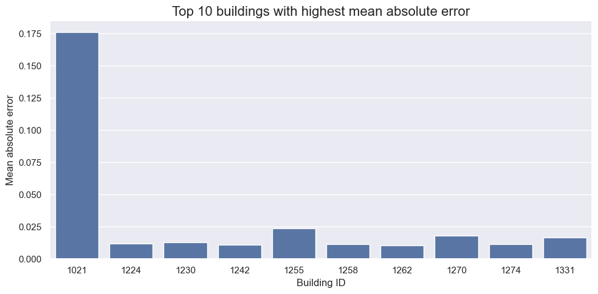

```python
val_df = X_hot_test.copy()

val_df['true'] = y_hot_test.values
val_df['pred'] = pred_orig_hot
val_df['residual'] = val_df['true'] - val_df['pred']

building_errors = val_df.groupby('building_id')['residual'].apply(lambda x: np.mean(np.abs(x)))
top_error_buildings = building_errors.sort_values(ascending=False).head(10)

plt.figure(figsize=(10, 5))
sns.barplot(x=top_error_buildings.index, y=top_error_buildings.values)

plt.title("Top 10 buildings with highest mean absolute error", fontsize=16)
plt.ylabel("Mean absolute error", fontsize=12)
plt.xlabel("Building ID", fontsize=12)
plt.xticks(fontsize=11)
plt.yticks(fontsize=11)
plt.tight_layout()
plt.show()
```

```python
building_errors.sort_values(ascending=False).head(10)
```

```
building_id
1021    0.176108
1255    0.023773
1270    0.017970
1331    0.016591
1230    0.013021
1224    0.011902
1274    0.011538
1258    0.011240
1242    0.010873
1262    0.010399
Name: residual, dtype: float64
```

#### **Error by Building: Top 10 Buildings with Highest Mean Absolute Error**

**1. Building 1021 stands out:**

- With a **MAE of 0.176**, it has **drastically higher error** than any other building in the list.
- This likely indicates an **anomaly**, such as:
  - Unique usage behavior (e.g., industrial process).
  - Poor model fit due to missing or misaligned features.
  - Data quality issues (sensor error, missing values).

**2. All other buildings have relatively low error:**

- MAE values range from **0.010 to 0.024**, which is **acceptable** and suggests:
  - The model performs **consistently well** across most buildings.
  - The features used (e.g., weather, time, primary use) generalize well to these buildings.

**3. Possible Actions:**

- **Investigate Building 1021:**
  - Compare its residual plot to others.
  - Look at its feature values and primary use — is it an outlier?
- **Cluster buildings by MAE:**
  - Group low-, medium-, and high-error buildings.
  - Examine what differentiates high-error groups.
- **Model adjustment:**
  - Consider building-specific models for high-error buildings.
  - Introduce more granular features (e.g., occupancy, retrofit status).
- **Error by hour of day**

```python
df = hot_water_train_dummy

# Recover hour from hour_sin and hour_cos
recovered_hour = np.arctan2(df['hour_sin'], df['hour_cos'])  # angle in radians
recovered_hour = np.degrees(recovered_hour)  # convert to degrees
recovered_hour = (recovered_hour + 360) % 360  # ensure positive angles
recovered_hour = (recovered_hour * 24) / 360   # scale to 0–24
recovered_hour = recovered_hour.round().astype(int) % 24  # round and wrap to 0–23
val_df['hour'] = recovered_hour
```

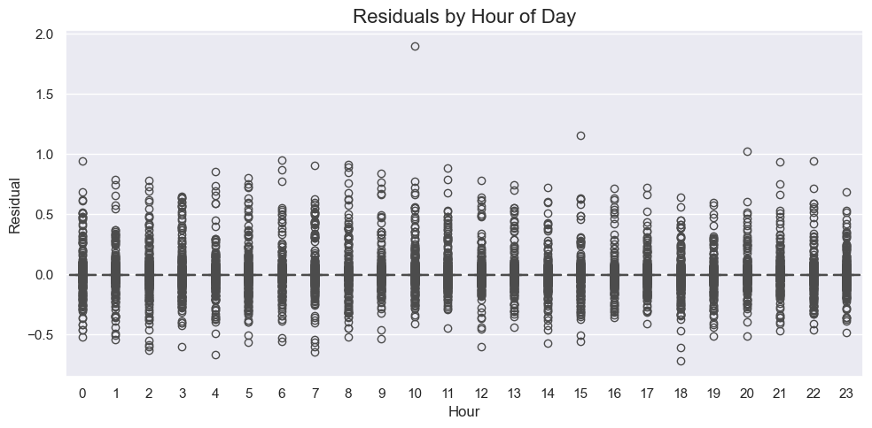

```python
# Plot
plt.figure(figsize=(10, 5))
sns.boxplot(x=val_df['hour'], y=val_df['residual'])

plt.title("Residuals by Hour of Day", fontsize=16)
plt.xlabel("Hour", fontsize=12)
plt.ylabel("Residual", fontsize=12)

#plt.ylim(-10., 10.)
plt.xticks(fontsize=11)
plt.yticks(fontsize=11)
plt.tight_layout()
plt.show()
```

#### **Residuals by hour of day**

**1. Overall Model Stability Across Time:**

- The residuals are **centered around 0 kWh** across **all 24 hours**, meaning the model is **not systematically biased** during specific times of the day.
- Most predictions fall within the range of **-0.5 to 1 kWh**, which reflects a **reasonable and stable performance**.

**3. Interpretation of Temporal Dynamics:**

- The **consistency across hours** may indicate that the model has successfully learned **daily usage patterns** (e.g., peaks in the morning/evening).
- The few outliers could be driven by **atypical events** (e.g., maintenance, equipment malfunction, or holidays).
- **Error by air temperature**

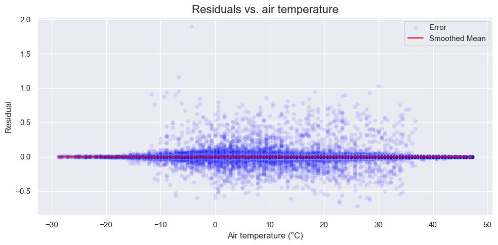

```python
plt.figure(figsize=(10, 5))

sns.scatterplot(x=val_df['air_temperature'], y=val_df['residual'], alpha=0.1, color='blue', label='Error')
sns.lineplot(x=val_df['air_temperature'], y=val_df['residual'].rolling(5000).mean(), color='red', label='Smoothed Mean')

plt.title("Residuals vs. air temperature", fontsize=16)
plt.xlabel("Air temperature (°C)", fontsize=12)
plt.ylabel("Residual", fontsize=12)

#plt.ylim(-1., 1.5)
plt.xticks(fontsize=11)
plt.yticks(fontsize=11)
plt.tight_layout()
plt.show()
```

#### **Residuals by air temperature**

1. **From -30°C to -10°C**:
   - Residuals are **very close to 0**, indicating stable model performance in cold conditions.
2. **From -10°C to 35°C**:
   - Residuals remain **centered around 0**, but show **greater dispersion**, extending to **±0.5 kWh**.
   - A lot number of **outliers** appear **outside this range**, suggesting performance variance under varying moderate temperatures.
3. **Above 35°C**:
   - Residuals are **very close to 0**, and **no significant outliers** are observed.
   - Indicates **strong model stability** during high-temperature conditions.

**Insight**:  
Model performance is most stable in very cold and very hot extremes, while **greater error variability occurs in the moderate temperature range** (-10°C to 35°C), likely due to more dynamic and complex demand behavior.

### **Save with joblib**

```python
import joblib

joblib.dump(model_orig_hot, "C:/Disc D/Projects to publish/Projects to do/Energy Efficiency Analytics in Buildings/hot_water_lgbm_model.pkl")
```

```
['C:/Disc D/Projects to publish/Projects to do/Energy Efficiency Analytics in Buildings/hot_water_lgbm_model.pkl']
```

## **4. Steam**

```python
# Load child water database
steam_train = pd.read_csv("C:/Disc D/Projects to publish/Projects to do/Energy Efficiency Analytics in Buildings/steam_train.csv")
```

```python
steam_train.shape
```

```
(2708713, 31)
```

### **Feature Engineering & data preparation**

**Enhance the dataset by adding useful dummied features and interaction features**

#### **a. Creating dummy variables for `site_id`, `primary_use` and `season` features**

```python
# Copying 'df_train_combined' dataframe into 'df_train_combined_dummy' dataframe
steam_train_dummy = steam_train.copy()

# Generate dummy variables and concatenate
for col in ["site_id", "primary_use", "season"]:
    dummies = pd.get_dummies(steam_train_dummy[col], prefix=col, drop_first=True)
    steam_train_dummy = pd.concat([steam_train_dummy, dummies], axis=1)
```

```python
steam_train_dummy.head(2)
```

|  | building_id | Energy_type | timestamp | site_id | primary_use | year_built | air_temperature | cloud_coverage | dew_temperature | precip_depth_1_hr | sea_level_pressure | wind_direction | wind_speed | square_meters | Energy_kWh | hour | dayofweek | month | is_weekend | is_work_hour | season | hour_sin | hour_cos | dayofweek_sin | dayofweek_cos | month_sin | month_cos | building_age | era_bin | … |
| --- | --- | --- | --- | --- | --- | --- | --- | --- | --- | --- | --- | --- | --- | --- | --- | --- | --- | --- | --- | --- | --- | --- | --- | --- | --- | --- | --- | --- | --- | --- |
| 0 | 745 | 2 | 2016-01-01 00:00:00 | 6 | Education | 1966.0 | 10.0 | 0.0 | 8.9 | 0.0 | 1017.5 | 150.0 | 0.0 | 1255.305336 | 0.000000 | 0 | 4 | 1 | 0 | 0 | Winter | 0.0 | 1.0 | -0.433884 | -0.900969 | 0.5 | 0.866025 | 59.0 | 60–80 | … |
| 1 | 747 | 2 | 2016-01-01 00:00:00 | 6 | Education | 1966.0 | 10.0 | 0.0 | 8.9 | 0.0 | 1017.5 | 150.0 | 0.0 | 2836.421493 | 0.035399 | 0 | 4 | 1 | 0 | 0 | Winter | 0.0 | 1.0 | -0.433884 | -0.900969 | 0.5 | 0.866025 | 59.0 | 60–80 | … |

```python
steam_train_dummy.shape
```

```
(2708713, 52)
```

- **Convert boolean values (True/False) to binary integers (1/0).**

```python
# Boolean features
bool_cols = ['site_id_7', 'site_id_9', 'site_id_13', 'site_id_14','site_id_15', 'primary_use_Entertainment/public assembly',
             'primary_use_Food sales and service', 'primary_use_Healthcare', 'primary_use_Lodging/residential',
             'primary_use_Manufacturing/industrial', 'primary_use_Office', 'primary_use_Other', 'primary_use_Parking',
             'primary_use_Public services', 'primary_use_Services', 'primary_use_Technology/science', 'primary_use_Utility',
             'primary_use_Warehouse/storage', 'season_Spring', 'season_Summer', 'season_Winter']

steam_train_dummy[bool_cols] = steam_train_dummy[bool_cols].astype(int)
```

```python
steam_train_dummy.head(2)
```

|  | building_id | Energy_type | timestamp | site_id | primary_use | year_built | air_temperature | cloud_coverage | dew_temperature | precip_depth_1_hr | sea_level_pressure | wind_direction | wind_speed | square_meters | Energy_kWh | hour | dayofweek | month | is_weekend | is_work_hour | season | hour_sin | hour_cos | dayofweek_sin | dayofweek_cos | month_sin | month_cos | building_age | era_bin | … |
| --- | --- | --- | --- | --- | --- | --- | --- | --- | --- | --- | --- | --- | --- | --- | --- | --- | --- | --- | --- | --- | --- | --- | --- | --- | --- | --- | --- | --- | --- | --- |
| 0 | 745 | 2 | 2016-01-01 00:00:00 | 6 | Education | 1966.0 | 10.0 | 0.0 | 8.9 | 0.0 | 1017.5 | 150.0 | 0.0 | 1255.305336 | 0.000000 | 0 | 4 | 1 | 0 | 0 | Winter | 0.0 | 1.0 | -0.433884 | -0.900969 | 0.5 | 0.866025 | 59.0 | 60–80 | … |
| 1 | 747 | 2 | 2016-01-01 00:00:00 | 6 | Education | 1966.0 | 10.0 | 0.0 | 8.9 | 0.0 | 1017.5 | 150.0 | 0.0 | 2836.421493 | 0.035399 | 0 | 4 | 1 | 0 | 0 | Winter | 0.0 | 1.0 | -0.433884 | -0.900969 | 0.5 | 0.866025 | 59.0 | 60–80 | … |

#### **b. Add the interaction features**

```python
# Add interaction features
steam_train_dummy = add_interaction_features(steam_train_dummy)
```

```python
steam_train_dummy.shape
```

```
(2708713, 173)
```

The sample data is composed of 2,708,713 rows and 173 features. Some unuseful features have to be dropped.

```python
steam_train_dummy.head(1)
```

|  | building_id | Energy_type | timestamp | site_id | primary_use | year_built | air_temperature | cloud_coverage | dew_temperature | precip_depth_1_hr | sea_level_pressure | wind_direction | wind_speed | square_meters | Energy_kWh | hour | dayofweek | month | is_weekend | is_work_hour | season | hour_sin | hour_cos | dayofweek_sin | dayofweek_cos | month_sin | month_cos | building_age | era_bin | … |
| --- | --- | --- | --- | --- | --- | --- | --- | --- | --- | --- | --- | --- | --- | --- | --- | --- | --- | --- | --- | --- | --- | --- | --- | --- | --- | --- | --- | --- | --- | --- |
| 0 | 745 | 2 | 2016-01-01 00:00:00 | 6 | Education | 1966.0 | 10.0 | 0.0 | 8.9 | 0.0 | 1017.5 | 150.0 | 0.0 | 1255.305336 | 0.0 | 0 | 4 | 1 | 0 | 0 | Winter | 0.0 | 1.0 | -0.433884 | -0.900969 | 0.5 | 0.866025 | 59.0 | 60–80 | … |

#### **c. Split the dataset into train and test subsets**

```python
# List of features to drop
fet_to_drop3 = ['Energy_type', 'timestamp', 'site_id', 'primary_use', 'year_built', 'Energy_kWh', 'hour', 'dayofweek',
                'month', 'era_bin', 'season', 'energy_density_kwh_m2', 'air_temp_bin', 'strata_key']

# train dataset
X_steam = steam_train_dummy.drop(columns = [col for col in fet_to_drop3 if col in steam_train_dummy.columns])
y_steam = steam_train_dummy['energy_density_kwh_m2']
```

```python
# We split two dataframes with inputs and targets, each into a train and test dataframe, and store them in variables.
X_steam_train, X_steam_test, y_steam_train, y_steam_test = train_test_split(X_steam, y_steam, test_size=0.3, random_state=42, shuffle=True)
```

```python
# Shape of train and test data subsets
print('Train subset shape: ', X_steam_train.shape)
print('Test subset shape: ', X_steam_test.shape)
```

```
Train subset shape:  (1896099, 161)
Test subset shape:  (812614, 161)
```

- The train dataset is composed of **1,896,099 rows** and **161 independant features**.
- The test dataset is composed of **812,614 rows** and **161 independant features**.

#### **d. Checking for Outliers**

- **Distribution Plot**

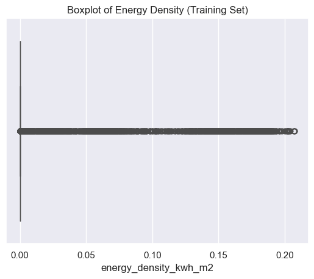

```python
# Example for Energy_kWh
sns.boxplot(x = y_steam_train)
plt.title("Boxplot of Energy Density (Training Set)")
plt.show()
```

As can be observed on the figure, there are a lot of outliers.

- **IQR method**

```python
Q1 = y_steam_train.quantile(0.25)
Q3 = y_steam_train.quantile(0.75)
IQR = Q3 - Q1

outlier_mask = (y_steam_train < (Q1 - 1.5 * IQR)) | (y_steam_train > (Q3 + 1.5 * IQR))
print(f"Outliers: {outlier_mask.sum()} / {len(y_steam_train)}")
```

```
Outliers: 181340 / 1896099
```

For energy density, we have about **181,340 outliers out of 1,896,099 rows** — that's only **~9.6%** of our data.

### **LGBMRegressor Model**

#### **a. IQR Outlier Handling**

Train the model, with "Energy Density" as target variable, on:

- **Original data**
- **Cleaned data (IQR-filtered)**
- **Clipped data (IQR-capped)**

```python
# ----- 1. Clip feature values (optional, for stability) -----
def iqr_clip_columns_inplace(df, cols=None, iqr_multiplier=1.5):
    if cols is None:
        cols = df.select_dtypes(include=np.number).columns

    for col in cols:
        q1 = df[col].quantile(0.25)
        q3 = df[col].quantile(0.75)
        iqr = q3 - q1
        lower = q1 - iqr_multiplier * iqr
        upper = q3 + iqr_multiplier * iqr
        df[col] = df[col].clip(lower=lower, upper=upper)

    return df

# Apply feature clipping
X_capped_steam = iqr_clip_columns_inplace(X_steam_train.copy())

# ----- 2. Compute target variable outliers -----
Q1 = y_steam_train.quantile(0.25)
Q3 = y_steam_train.quantile(0.75)
IQR = Q3 - Q1
lower_bound = Q1 - 1.5 * IQR
upper_bound = Q3 + 1.5 * IQR

outlier_mask = (y_steam_train < lower_bound) | (y_steam_train > upper_bound)
print(f"Outliers in target: {outlier_mask.sum()} / {len(y_steam_train)}")

# ----- Option A: Clip the target variable -----
y_capped_steam = y_steam_train.clip(lower=lower_bound, upper=upper_bound)

# ----- Option B: Filter out outlier rows completely -----
X_filtered_steam = X_capped_steam[~outlier_mask]
y_filtered_steam = y_steam_train[~outlier_mask]
```

```
Outliers in target: 181340 / 1896099
```

```python
X_steam_train.shape
```

```
(1896099, 161)
```

```python
X_filtered_steam.shape
```

```
(1714759, 161)
```

**The dataset without outliers is composed by 1,714,759 rows.**

#### **b. Train models and compare**

```python
# Original data
model_orig_steam = train_lgbm(X_steam_train, y_steam_train)
pred_orig_steam = model_orig_steam.predict(X_steam_test)
evaluate_model("Original", y_steam_test, pred_orig_steam)

# IQR-filtered data
model_filtered_steam = train_lgbm(X_filtered_steam, y_filtered_steam)
pred_filtered_steam = model_filtered_steam.predict(X_steam_test)
evaluate_model("Filtered (IQR removed)", y_steam_test, pred_filtered_steam)

# IQR-capped data
model_capped_steam = train_lgbm(X_capped_steam, y_capped_steam)
pred_capped_steam = model_capped_steam.predict(X_steam_test)
evaluate_model("Capped (IQR clipped)", y_steam_test, pred_capped_steam)
```

```
[LightGBM] [Warning] Found whitespace in feature_names, replace with underlines
[LightGBM] [Info] Auto-choosing col-wise multi-threading, the overhead of testing was 1.128377 seconds.
You can set `force_col_wise=true` to remove the overhead.
[LightGBM] [Info] Total Bins 8795
[LightGBM] [Info] Number of data points in the train set: 1896099, number of used features: 161
[LightGBM] [Info] Start training from score 0.000159
--- Original ---
RMSE: 0.0010524305922686753
MAE: 5.07844953533863e-05
Median AE: 7.59421196441978e-06
R²: 0.9262313913733774
SMAPE: 92.63 %

[LightGBM] [Warning] Found whitespace in feature_names, replace with underlines
[LightGBM] [Info] Auto-choosing col-wise multi-threading, the overhead of testing was 0.304228 seconds.
You can set `force_col_wise=true` to remove the overhead.
[LightGBM] [Info] Total Bins 6052
[LightGBM] [Info] Number of data points in the train set: 1714759, number of used features: 44
[LightGBM] [Info] Start training from score 0.000016
--- Filtered (IQR removed) ---
RMSE: 0.003876667009982964
MAE: 0.0001366101300777687
Median AE: 2.637263480346313e-06
R²: -0.000925287806603059
SMAPE: 66.62 %

[LightGBM] [Warning] Found whitespace in feature_names, replace with underlines
[LightGBM] [Info] Auto-choosing col-wise multi-threading, the overhead of testing was 0.350114 seconds.
You can set `force_col_wise=true` to remove the overhead.
[LightGBM] [Info] Total Bins 6084
[LightGBM] [Info] Number of data points in the train set: 1896099, number of used features: 44
[LightGBM] [Info] Start training from score 0.000022
--- Capped (IQR clipped) ---
RMSE: 0.0038752656331161157
MAE: 0.00013456285640049305
Median AE: 2.809338107301576e-06
R²: -0.00020176937500071546
SMAPE: 65.64 %
```

#### **Interpretations:**

**1. Original Dataset (No Outlier Handling)**

- **Strong R² (92.6%)** shows excellent explanatory power — the model captures the variability in steam usage quite well.
- **Very low errors (MAE, Median AE)** indicate highly accurate predictions.
- **High SMAPE (92.6%)**, however, is concerning — likely caused by very **small actual values in the denominator**, which inflates SMAPE disproportionately even with tiny prediction errors.
- This version likely includes extreme values (outliers), which the model handles reasonably well.

**2. IQR Filtered Dataset (Outliers Removed)**

- **Drastically worse RMSE/MAE and negative R²**: This suggests that after removing outliers, the model **underfits** — it performs **worse than a simple mean baseline**.
- **Median AE is extremely low**, meaning that **most predictions are accurate**, but some large errors still exist — possibly because **useful variance** was mistakenly removed with the outliers.
- **SMAPE improves** (66.6% vs 92.6%) — outlier removal seems to **stabilize percentage errors**, especially if some extreme low targets were filtered out.

**3. IQR Capped Dataset (Outliers Clipped)**

- **Performance very similar to filtered version** — still **underperforming** relative to the original model.
- Slight improvement in **SMAPE** and **R²**, but still close to 0 — capping avoids information loss but might still distort key patterns.
- Like filtering, clipping **removes the model's ability to learn from real variation**, especially important for steam usage, which is often **sparse and bursty**.

**Recommendations:**

1. **Stick with the Original model for now** — it has the **highest predictive power** and **lowest error**, even if SMAPE is inflated.
2. **Address SMAPE inflation by**:
   - Using **alternative metrics** (e.g., MAE, RMSE) for model evaluation.
   - Filtering or analyzing SMAPE **by value bins** to see where the problem is localized (e.g., very low steam usage).
3. Consider **log-transforming** the target variable (with a shift if needed) to stabilize the variance if steam values are highly skewed.

### **Feature importances**

- **Get N top important features**

```python
# Get absolute and relative importances
importances = model_orig_steam.feature_importances_
features = X_steam.columns
relative_importances = importances / importances.sum()

# Select the top N features
top_N = 68  # Change this to the desired number of features
top_features, top_importances = select_top_features(relative_importances, features, N=top_N)

print(f"Top {top_N} Features:")
print(' ')
for i, (feature, importance) in enumerate(zip(top_features, top_importances), 1):
    print(f"{i}. {feature}: {importance:.7f}")

Sum_top = top_importances.sum()
print(' ')
print(f" Sum of the Top {top_N} Features Importances: {Sum_top:.3f}")
```

```
Top 68 Features:

1. square_meters: 0.1202000
2. building_id: 0.0840333
3. sea_level_pressure_x_month_cos: 0.0549333
4. sea_level_pressure: 0.0469000
5. dew_temperature: 0.0358333
6. wind_speed_x_square_meters: 0.0325667
7. air_temperature: 0.0317000
8. air_temperature_x_square_meters: 0.0317000
9. wind_direction_x_month_cos: 0.0306333
10. wind_direction: 0.0301000
11. dew_temperature_x_month_cos: 0.0294333
12. air_temperature_x_month_cos: 0.0291000
13. dew_temperature_x_square_meters: 0.0284667
14. month_sin: 0.0280000
15. building_age: 0.0260000
16. wind_speed_x_month_cos: 0.0246667
17. cloud_coverage_x_month_cos: 0.0223000
18. hour_sin: 0.0191333
19. dayofweek_sin: 0.0163000
20. cloud_coverage_x_hour_cos: 0.0155000
21. wind_direction_x_hour_cos: 0.0150333
22. wind_speed_x_hour_cos: 0.0147333
23. air_temperature_x_hour_cos: 0.0144667
24. square_meters_x_hour_cos: 0.0141333
25. dew_temperature_x_hour_cos: 0.0141000
26. wind_speed: 0.0129667
27. dayofweek_cos: 0.0114667
28. square_meters_x_is_weekend: 0.0103667
29. building_age_x_hour_cos: 0.0101667
30. square_meters_x_is_work_hour: 0.0099667
31. sea_level_pressure_x_hour_cos: 0.0087667
32. sea_level_pressure_x_is_work_hour: 0.0072333
33. precip_depth_1_hr_x_month_cos: 0.0069667
34. site_id_13: 0.0066667
35. wind_speed_x_is_weekend: 0.0063667
36. sea_level_pressure_x_is_weekend: 0.0061667
37. month_cos: 0.0059000
38. wind_speed_x_is_work_hour: 0.0054333
```

[output cut: 17 more lines]

```
56. primary_use_Services_x_hour_cos: 0.0017333
57. hour_cos: 0.0016667
58. primary_use_Services_x_season_Spring: 0.0016000
59. primary_use_Office: 0.0012333
60. primary_use_Services_x_dayofweek_cos: 0.0011000
61. primary_use_Services_x_season_Winter: 0.0009667
62. primary_use_Manufacturing/industrial_x_hour_cos: 0.0009667
63. primary_use_Office_x_season_Winter: 0.0009333
64. primary_use_Office_x_hour_cos: 0.0009000
65. primary_use_Public services_x_dayofweek_cos: 0.0007667
66. primary_use_Utility_x_hour_cos: 0.0007667
67. primary_use_Public services_x_hour_cos: 0.0006667
68. primary_use_Warehouse/storage: 0.0006333

 Sum of the Top 68 Features Importances: 0.990
```

- **Get the top interaction features**

```python
# Convert to pandas Series first
top_features_series = pd.Series(top_features)

# Then filter and sort
top_intera_feats = top_features_series[top_features_series.str.contains('_x_')]
print(top_intera_feats)

print(len(top_intera_feats))
```

```
2                      sea_level_pressure_x_month_cos
5                          wind_speed_x_square_meters
7                     air_temperature_x_square_meters
8                          wind_direction_x_month_cos
10                        dew_temperature_x_month_cos
11                        air_temperature_x_month_cos
12                    dew_temperature_x_square_meters
15                             wind_speed_x_month_cos
16                         cloud_coverage_x_month_cos
19                          cloud_coverage_x_hour_cos
20                          wind_direction_x_hour_cos
21                              wind_speed_x_hour_cos
22                         air_temperature_x_hour_cos
23                           square_meters_x_hour_cos
24                         dew_temperature_x_hour_cos
```

[output cut: 33 more lines]

**From these 68 top important features, 46 ones are interaction features.**

#### **Interpretations:**

**1. Overall Feature Influence**

- The **top 68 features** account for **99.0%** of the total model importance, indicating that the model relies heavily on a focused subset of features for accurate predictions.
- This suggests effective feature engineering and dimensionality reduction — your model isn't overly dependent on noisy or redundant variables.

**2. Key Contributors**

- `square_meters` (**12%**) is the most important feature, which aligns with expectations: energy usage typically scales with building size.
- `building_id` (**8.4%**) being second-highest indicates strong site-specific patterns — this may reflect fixed characteristics like design, insulation, HVAC systems, or occupancy patterns.

**3. Dominant Weather Features**

Several raw and engineered weather features are highly important:

- `sea_level_pressure` and **its interaction with month** (5.4% + 4.7%)
- `dew_temperature` and `air_temperature` (and their interactions with `month_cos`, `hour_cos`, `square_meters`)
- `wind_speed`, `wind_direction`, and their interactions

The model detects **seasonal and temporal weather dependencies** in building energy behavior, which is expected as HVAC use responds to external conditions.

**4. Time and Cyclical Effects**

- **Cyclical encodings** such as `month_sin`, `hour_sin`, `dayofweek_sin`, and `dayofweek_cos` have non-negligible importance.
- This indicates that the model captures **weekly and daily usage rhythms** — e.g., working hours, weekends, or school hours.

**5. Engineered Interaction Features (46 out of 68)**

A large portion of your most important features are interactions, such as:

- Weather × Time: `air_temperature_x_hour_cos`, `dew_temperature_x_month_cos`, etc.
- Weather × Building: `wind_speed_x_square_meters`
- Building × Time: `building_age_x_hour_cos`, `square_meters_x_is_work_hour`
- Use-type × Season: `primary_use_Services_x_season_Winter`

**Insight**: These interactions are **crucial** to modeling the nuanced behavior of energy consumption. For instance:

- A larger building reacts differently to temperature changes than a smaller one.
- Offices consume energy differently on weekends vs weekdays.

This confirms the **value of domain-informed feature engineering** in energy analytics.

**6. Primary Use Variables**

- Features like `primary_use_Services`, `primary_use_Office`, and their interactions with `hour`, `season`, etc., are included but less dominant.
- This implies that **building function matters**, but the **dynamic and physical factors** (**weather**, **size**, and **timing**) carry more predictive power.

**Conclusion**

Your model's decision-making is driven by a **well-balanced mix** of:

- Static building characteristics (e.g., size, ID, age)
- Dynamic environmental conditions (e.g., temperature, pressure)
- Temporal structure (e.g., hour, month)
- Engineered interactions that amplify the above

This diversity and balance in important features is a **strong signal** of a well-performing and **interpretable model**, especially for applications like energy forecasting, where both physical laws and behavioral patterns matter.

To better understand how each feature influences the model's predictions, we use SHAP (SHapley Additive exPlanations), a game-theoretic approach to explain individual predictions. SHAP values provide both global insights into feature importance and local explanations for specific instances.

#### **1. SHAP Setup**

```python
import shap

# Compute SHAP values
explainer = shap.TreeExplainer(model_orig_steam)
shap_values = explainer.shap_values(X_steam_test)
```

#### **2. SHAP Summary Plot (Global Importance)**

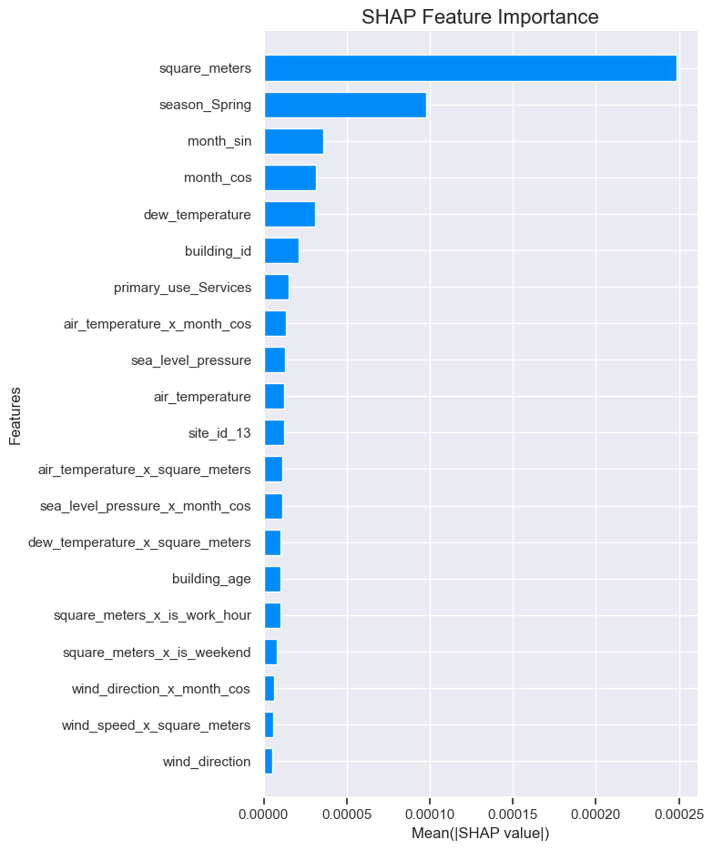

```python
# Create SHAP bar plot
shap.summary_plot(shap_values, X_steam_test, plot_type="bar", show=False)

# Customize title and label fonts
plt.title("SHAP Feature Importance", fontsize=16)
plt.xlabel("Mean(|SHAP value|)", fontsize=12)
plt.ylabel("Features", fontsize=12)

# Customize tick label size
plt.xticks(fontsize=11)
plt.yticks(fontsize=11)

# Show the customized plot
plt.tight_layout()
plt.show()
```

```python
# Convert to DataFrame for easier analysis
shap_df = pd.DataFrame(shap_values, columns= X_steam_test.columns)

# Compute mean absolute SHAP values per feature
mean_abs_shap = shap_df.abs().mean().sort_values(ascending=False)

# Select top 20 features
top_20_features = mean_abs_shap.head(20).index

# Extract SHAP values for these features
top_20_shap_values = shap_df[top_20_features]

# Display result
print("SHAP values of top 20 features:")
top_20_shap_values.abs().mean().sort_values(ascending=False)
```

```
SHAP values of top 20 features:
```

```
square_meters                      0.000249
season_Spring                      0.000098
month_sin                          0.000036
month_cos                          0.000032
dew_temperature                    0.000031
building_id                        0.000021
primary_use_Services               0.000015
air_temperature_x_month_cos        0.000013
sea_level_pressure                 0.000013
air_temperature                    0.000012
site_id_13                         0.000012
air_temperature_x_square_meters    0.000011
sea_level_pressure_x_month_cos     0.000011
dew_temperature_x_square_meters    0.000010
building_age                       0.000010
square_meters_x_is_work_hour       0.000010
square_meters_x_is_weekend         0.000008
wind_direction_x_month_cos         0.000006
wind_speed_x_square_meters         0.000006
wind_direction                     0.000005
dtype: float64
```

#### **SHAP-based interpretation of model behavior**

**Interpretation of Top Features**

**1. square_meters (0.000249)**

- Most influential feature.
- Larger buildings tend to consume more energy — makes intuitive sense.
- SHAP confirms the model strongly uses building size to make predictions.

**2. season_Spring (0.000098)**

- Indicates seasonality is important.
- Spring may involve moderate HVAC usage, influencing energy use patterns distinctly.

**3–4. month_sin (0.000036) & month_cos (0.000032)**

- Together, these encode cyclical seasonality (Jan–Dec).
- Confirms that time of year meaningfully affects energy demand (heating/cooling).

**5. dew_temperature (0.000031)**

- Affects perceived air temperature and HVAC load.
- More humid air = more energy to cool = more influence.

**6. building_id (0.000021)**

- Captures building-specific characteristics not directly in the features.
- Could reflect hidden patterns (e.g., occupancy, inefficiencies, design).

**Takeaways**

- The model heavily relies on:
  - **Building size**
  - **Seasonality**
  - **Temperature and humidity**
  - **Interaction terms** (especially with time/month)
  - **Specific locations (site/building ID)**
- It uses **domain-relevant interactions** (e.g., square meters x weather or time), showing a well-structured feature engineering pipeline.

#### **3. SHAP Dependence (Nonlinear Interaction)**

- **Air-temperature**

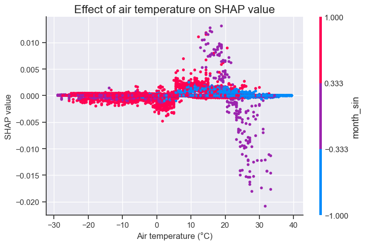

```python
# Plot SHAP dependence with show=False
shap.dependence_plot("air_temperature", shap_values, X_steam_test, show=False)

# Customize title and labels
plt.title("Effect of air temperature on SHAP value", fontsize=16)
plt.xlabel("Air temperature (°C)", fontsize=12)
plt.ylabel("SHAP value", fontsize=12)

# Customize tick label size
plt.xticks(fontsize=11)
plt.yticks(fontsize=11)

# Adjust layout and show the customized plot
plt.tight_layout()
plt.show()
```

#### **SHAP Value Ranges by Air Temperature**

Steam is typically used for:

- Space heating (especially in cold months)
- Hot water supply
- Industrial or institutional processes (e.g., hospitals, labs, manufacturing)

**Key insights:**

**Color gradient (month_sin) shows a clear seasonal interaction:**

Same air temperature (e.g., 15°C) can have a different SHAP impact depending on the month:

- **In winter**, it might still mean relatively lower heating demand → **lower steam use**.
- **In summer**, even moderate temperatures signal very low heating needs → **negative SHAP**.

#### **4. Error distribution (Residuals)**

- **Histogram of Residuals**

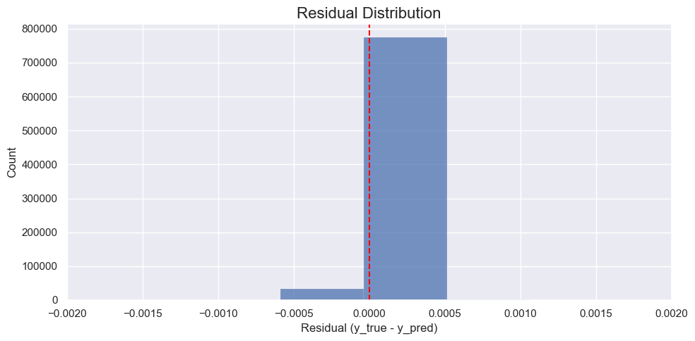

```python
residuals = y_steam_test - pred_orig_steam

plt.figure(figsize=(10, 5))
sns.histplot(residuals, bins=500, kde=False)
plt.axvline(0, color='red', linestyle='--')
plt.title("Residual Distribution", fontsize=16)
plt.xlabel("Residual (y_true - y_pred)", fontsize=12)

plt.xlim(-0.002, 0.002)
plt.xticks(fontsize=11)
plt.yticks(fontsize=11)
plt.tight_layout()
plt.show()
```

#### **Error Distribution (Residuals Analysis)**

**Overall Shape**

- The histogram shows that **most residuals** (differences between actual and predicted values: `y_true - y_pred`) are **very close to zero**.
- There is a **strong peak centered just above 0**, with the vast majority of residuals in a very narrow range:

approximately **between 0 and 0.0005**.

**Model Bias**

- The red dashed line (at **0**) is the reference for zero residuals.
- Since the bulk of residuals is centered **slightly right of 0**, the model shows a **very small positive bias** — meaning:

→ The model **slightly underpredicts steam consumption** in most cases, but the error is minimal.

**Outliers**

- A **small tail** on the **negative side** extends to around **-0.0015**, suggesting a few cases where:

→ The model **overestimates** steam usage more than usual.

- On the **positive side**, the tail is extremely short — **almost no large underpredictions** occur.

→ This indicates **rare severe underprediction**, and more frequent (but still rare) overpredictions.

**Data Volume**

- There are **~800,000+* residuals** tightly packed in that narrow band, suggesting:
  - The **model is highly accurate overall,** with **tiny residual errors**.
  - The **data was likely normalized or scaled**, since residual values are in the range of ±0.002 — extremely small.

**Implication in Steam Context**

- Steam is typically used in **heating**, **sterilization**, or **industrial processes**, where control and predictability are crucial.
- This residual distribution tells us:
  - Your model performs **very well**, rarely making large errors.
  - But it **slightly underpredicts**, which could matter in **cost/energy planning** if left uncorrected.

#### **5. Error analysis by building, time, and weather**

- **Error by building_id**

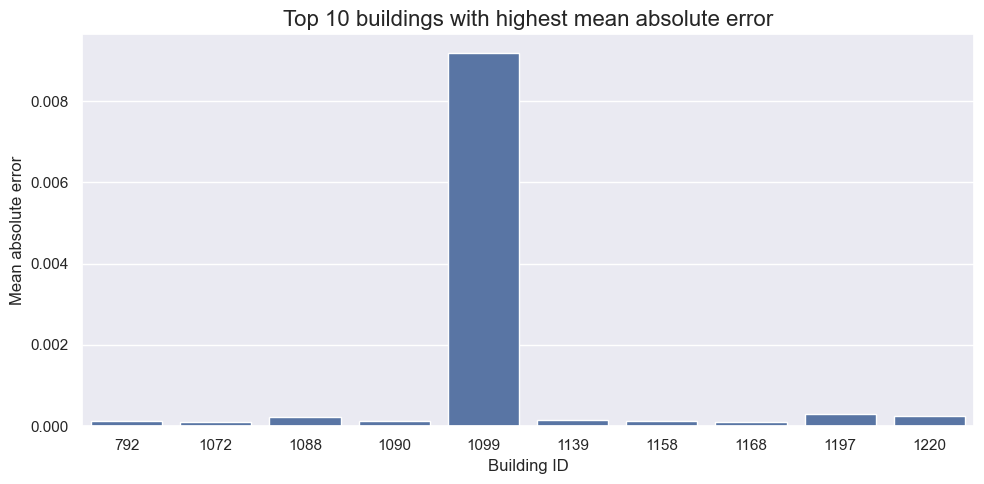

```python
val_df = X_steam_test.copy()

val_df['true'] = y_steam_test.values
val_df['pred'] = pred_orig_steam
val_df['residual'] = val_df['true'] - val_df['pred']

building_errors = val_df.groupby('building_id')['residual'].apply(lambda x: np.mean(np.abs(x)))
top_error_buildings = building_errors.sort_values(ascending=False).head(10)

plt.figure(figsize=(10, 5))
sns.barplot(x=top_error_buildings.index, y=top_error_buildings.values)

plt.title("Top 10 buildings with highest mean absolute error", fontsize=16)
plt.ylabel("Mean absolute error", fontsize=12)
plt.xlabel("Building ID", fontsize=12)
plt.xticks(fontsize=11)
plt.yticks(fontsize=11)
plt.tight_layout()
plt.show()
```

```python
building_errors.sort_values(ascending=False).head(10)
```

```
building_id
1099    0.009185
1197    0.000291
1220    0.000255
1088    0.000236
1139    0.000155
1158    0.000140
1090    0.000130
792     0.000125
1072    0.000104
1168    0.000099
Name: residual, dtype: float64
```

#### **Error by Building: Top 10 Buildings with Highest Mean Absolute Error**

**1. Building 1099 is a major outlier**

- Its MAE (**0.009185**) is **~30× higher** than the next worst building (1197).
- It likely has:
  - Unusual or erratic steam usage behavior.
  - Poor model fit (e.g. due to missing/corrupted features).
  - Possibly different function (e.g. industrial rather than office).
- This building **deserves deeper investigation** — could be skewing overall model performance.

**2. The rest are very low**

- All other buildings have MAE < 0.0003 — extremely low errors.
- This reinforces that:

→ The **model is performing extremely well** for most buildings.

**3. Consistent prediction quality**

- The tight range in MAE from buildings ranked 2 to 10 suggests **stable generalization** across different sites.

**Investigate Building 1099:**

- Plot actual vs predicted steam usage over time.
- Check if there are missing or extreme outlier inputs.
- See if it uses steam differently (e.g. production facility, hospital, etc.).

**Compare Feature Distributions:**

- Compare 1099’s features (e.g. temperature, primary use, square footage, etc.) to buildings with low MAE.

**Model Error Analysis:**

- If you’re doing multi-building training, consider:
  - Adding **building-specific features** or embeddings.
  - Using **per-building models** for large outliers like 1099.

### **Save with joblib**

```python
import joblib

joblib.dump(model_orig_steam, "C:/Disc D/Projects to publish/Projects to do/Energy Efficiency Analytics in Buildings/steam_lgbm_model.pkl")
```

## **Conclusion – Part 1: Data Exploration, Modeling, and Interpretation**

In this first phase of the project, we established a complete pipeline for analyzing and modeling building energy consumption. Beginning with raw data import and preprocessing, we carefully prepared and standardized the datasets, addressed missing values, and engineered additional features to better capture temporal, weather, and operational effects. Through exploratory data analysis (EDA), we uncovered meaningful patterns at the portfolio, building, and energy-type levels—highlighting both expected seasonal/temporal dependencies and structural variations across buildings.

To gain deeper insights, we disaggregated the analysis by energy type (electricity, chilled water, steam, and hot water), recognizing that each system exhibits distinct drivers and consumption behaviors. This separation allowed us to design predictive models that more accurately reflect system-specific dynamics. Using the LightGBM Regressor with robust handling of outliers, we trained and evaluated models for each energy type, supported by interpretability tools such as feature importances and SHAP values. These revealed not only the key variables influencing energy consumption but also the magnitude and direction of their effects. Error analysis further contextualized model performance, identifying cases where predictions aligned well with actual data and areas where discrepancies suggest operational complexity or data quality issues.

Overall, Part 1 demonstrates that data-driven modeling can effectively capture the drivers of building energy consumption while ensuring interpretability for decision-makers. This work provides a solid foundation for moving into the second phase of the project, where we will exploit unlabeled datasets to generate forecasts, detect anomalies, and design predictive strategies for enhanced energy efficiency and building management.